# Bagged trees

# About bagged tree models

A single classification tree can have high variance; that is, different subsets of data can lead to very different trees. Bagging – short for “bootstrap aggregating” – can decrease that variance by combining multiple classification trees into one model. In other words, the average of multiple “guesses” tends to be closer to the real answer than a single “guess”. The bagging procedure is as follows:  
1. Take a random sample of the data with replacement (the “bootstrap”)  
2. Create a full unpruned tree using that sample, using all predictors  
3. Record the predicted outcomes from the tree  
4. Repeat for ‘x’ number of trees as specified by the user, e.g. a model could have 10 or 100 trees  
5. If it’s a binary outcome, take the majority vote across the trees’ predictions; or if it’s a continuous outcome, take the average across the trees’ predictions (the “aggregating”)

# Data

All participants included in this analysis had PTA > 25 in the better ear, with complete data across the 28 predictors of interest (n=753).

# Bagged tree model

To find out how many repetitions of the bagging procedure are appropriate (i.e. how many individual classification trees should be created and aggregated into one model), models with different numbers of trees were built, and their error measured. Too many trees won’t lead to overfitting, but will take unnecessary computing time, so it’s better to use the smallest number of trees that leads to the lowest error.

The plot below shows that classification error decreases as the number of trees in a bagged model increases, up to a point. Beyond 200 trees, the error rate doesn’t decrease much more, so 200 trees is a reasonable number to use.

The error rate is the “out-of-bag” error: when a bootstrapped sample of data is randomly selected with replacement from the dataset, some of the observations are not part of the sample (“out-of-bag”). Each tree is built from observations that have been sampled, and then tested on out-of-bag observations to get the out-of-bag error. The black line is the average out-of-bag error for 10 bagged models with that particular number of trees, and the gray lines are +/- 1 SD.

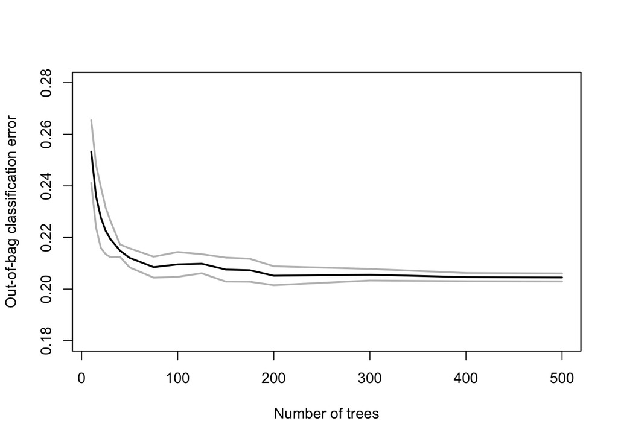

According to the plot above, 200 trees should be a sufficiently large number in this model, so the *nbagg* parameter was set to 200. For individual trees, the complexity parameter was set to *cp* = 0 to allow each tree to grow to its full depth; otherwise the same parameters were used as in the simple classification tree: a *minsplit* of 20 observations for splitting a node, *maxcompete* = FALSE, *maxsurrogate* = 0, and split = “gini”.

Each individual tree was built on a bootstrapped sample of n=753, randomly sampled with replacement from the original dataset of n=753. On average, each observation appeared in 127 of 200 trees (range 104 to 153). On average, each tree was built from 477 unique observations (range 449 to 498), with the remaining observations being duplicates that were resampled by chance. In other words, roughly two-thirds of the data were used to build each individual tree, each time.

*Technical note: The bagging( ) function in ipred doesn’t seem to be able to incorporate case weights even though it’s based on rpart( ), which does have an option for case weights. But it doesn’t matter because there’s no option to stratify each bootstrapped sample by ‘Yes’ and ‘No’ cases anyway. The imbalanced dataset (more ‘No’ cases than ‘Yes’) and lack of case weights might explain the bias towards ‘No’ cases in the final model.*

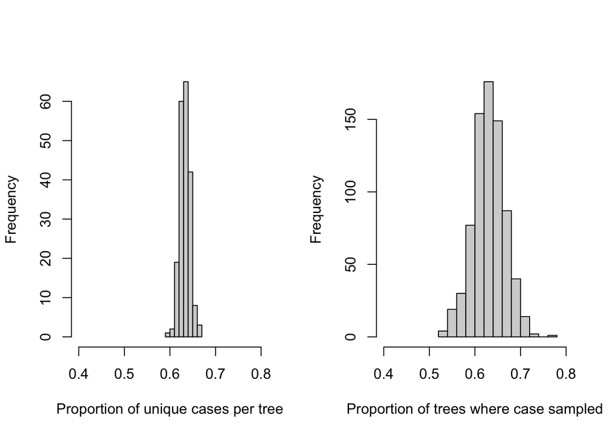

# Model performance

The table below shows the bagged model’s confusion matrix of correctly and incorrectly predicted cases. The model’s classification accuracy was 87% overall, with 100% specificity but somewhat poor sensitivity (33%).

```
##       Predicted
## Actual  No Yes
##    No  604   0
##    Yes 100  49
```

# Variable importance

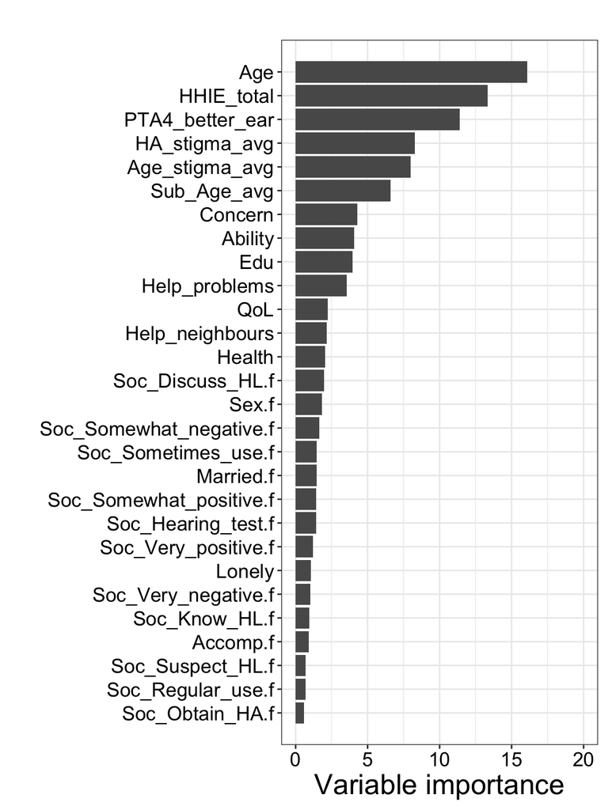

# Takeaways

1. Like in a single 12-split classification tree, Age and HHIE are the 1st and 2nd most important variables in a bagged model. Unlike the single tree, which has Age Stigma as its 3rd most important variable, PTA is the 3rd most important variable in a bagged model, followed by HA Stigma and Age Stigma.
2. There is likely a bigger bias towards ‘No’ cases in the bagged model than in the single tree, as case weights couldn’t be incorporated in the bagged model and ‘No’ cases were 4x the number of ‘Yes’ cases. This bias would also explain the much higher specificity and lower sensitivity in the bagged model (100%, 33%) compared to the single tree model (61%, 82%).